# Archaeological Science as Community Enterprise

02/04/2015 | [CAA 2015- KEEP THE REVOLUTION GOING](http://caaconference.org)

## Outline

## Outline

- Scientific Community
- Similarities with FS Community
- Concepts of Reuse, Modulation and Reproducibility
- 2 examples
- Conclusion

## The scientific community

## Diversity makes the difference

- Science is cumulative
- Point of views
- Diversity invigorates problem solving

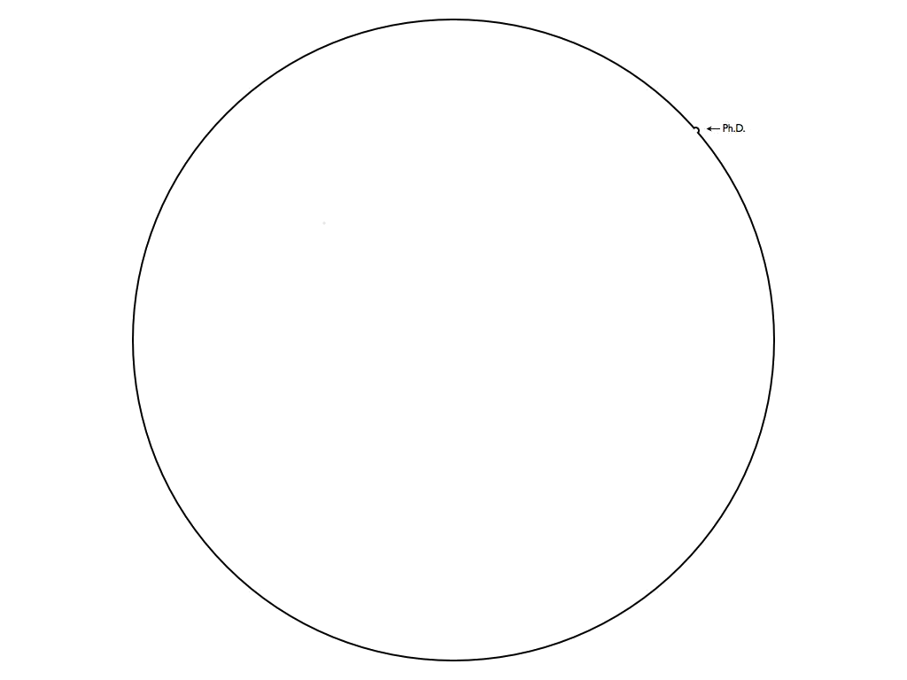

## Functions of the scientific community

- Inspiration
- Motivation
- Scrutiny

[figure not shown]

## FS and Free Science

## Some similarities

- Peer review
- Validation and replication
- Culture of credit, civility
- Reputation
- Communication

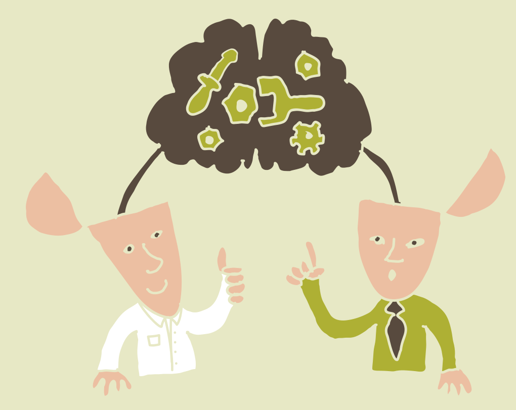

## Modifiability

- Century of acclimatization to stable knowledge
- FS are in constant modulation

[figure not shown]

## Chalenge the Power of Knowledge

[figure not shown]

## Reproducibility

## Reuse and Reproducibility

- "We often forget that scientific knowledge is reliable not because scientists are more clever, objective or honest than other people, but because their claims are exposed to criticism and replication." (Fanelli 2013)

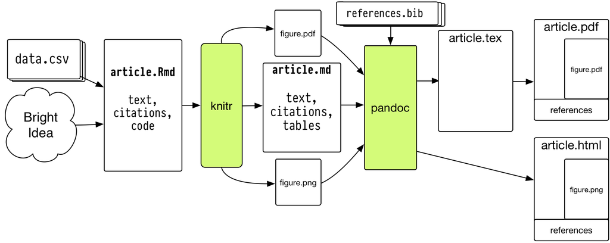

## Pedagogy

In pedagogical terms, Windows is to fish as UNIX is to fishing lessons.

- Lions' Commentary on UNIX 6th Edition

[figure not shown]

## Pedagogy

In pedagogical terms, Windows is to fish as UNIX is to fishing lessons.

- Lions' Commentary on UNIX 6th Edition
- An R Companion to Quantifying Archaeology by Stephen Shennan from David L. Carlson

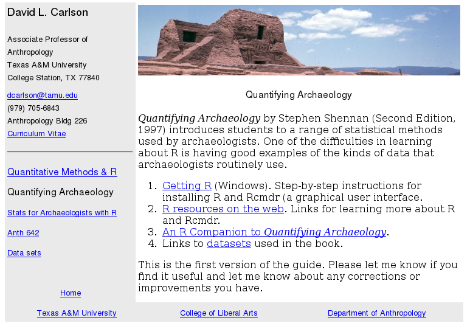

## Pedagogy

In pedagogical terms, Windows is to fish as UNIX is to fishing lessons.

- Lions' Commentary on UNIX 6th Edition
- An R Companion to Quantifying Archaeology by Stephen Shennan from David L. Carlson
- Quantitative Archaeology Wiki

[figure not shown]

## Blurring the border

- (Archaeological) project with R on Hittite seals

[figure not shown]

## Blurring the border

- (Archaeological) project with R on Hittite seals
- Turn into statistic question

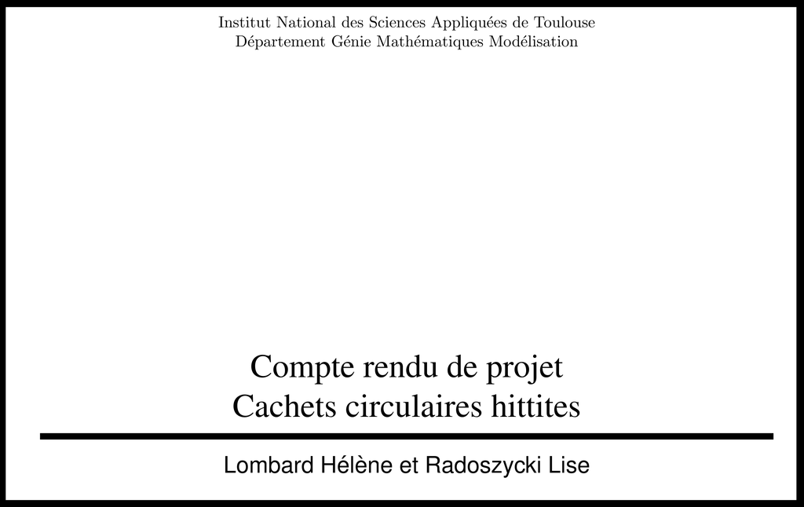

## Blurring the border

- (Archaeological) project with R on Hittite seals
- Turn into statistic question
- Mixing of competences

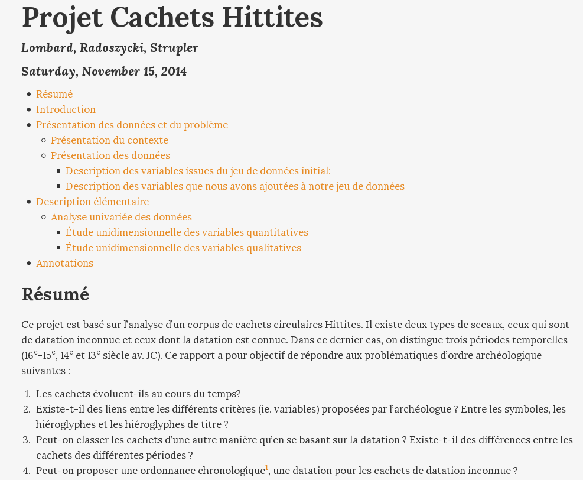

## The Conclusion

## Key points

- effect of FS in Science
- new perspective
- need for further advocacy for FS
- Open question: how far FS challenge knowledge transmission?

## Colophon

Presentation written in [Markdown](http://daringfireball.net/projects/markdown/) ([R Presentation](http://www.rstudio.com/ide/docs/presentations/overview))

Compiled into HTML5 using [RStudio](http://www.rstudio.com/ide/)

Source code hosting: https://github.com/nehemie/Slideshow

ORCID: http://orcid.org/0000-0002-2898-6217

### Licensing:

Presentation: [CC BY 4.0](http://creativecommons.org/licenses/by/4.0/)

Source code: MIT

## Backup slide

### Publishing and Pushing

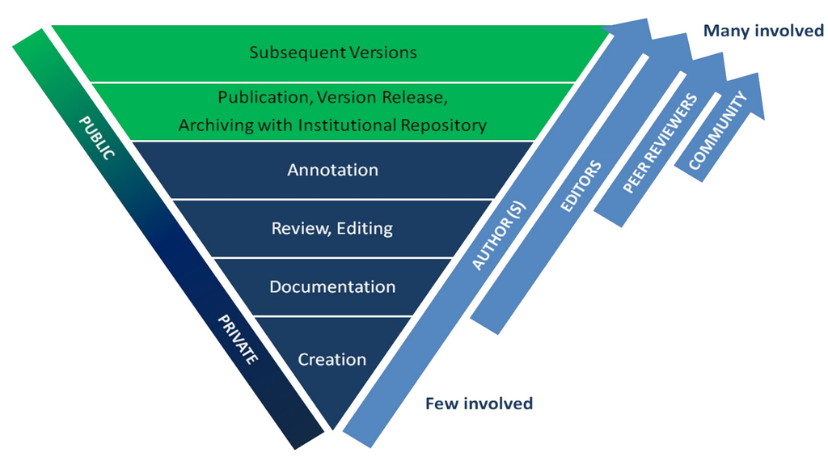

## References

Fanelli, Daniele. 2013. “Redefine Misconduct as Distorted Reporting.” *Nature* 494: 149. doi:10.1038/494149a.

Kansa, Eric C., Sarah Whitcher Kansa, and Benjamin Arbuckle. 2014. “Publishing and Pushing: Mixing Models for Communicating Research Data in Archaeology.” *International Journal of Digital Curation* 9.1: 57–70. doi:10.2218/ijdc.v9i1.301.

Kelty, Christopher M. 2001. “Free Software/Free Science.” *First Monday* 6 (12). http://pear.accc.uic.edu/ojs/index.php/fm/article/view/902.

———. 2008. *Two Bits: The Cultural Significance of Free Software*. Experimental Futures. Durham: Duke University Press. http://twobits.net/pub/Kelty-TwoBits.pdf.

Vinck, Dominique, and Claire Clivaz. 2014. “Les Humanités Délivrées. Savoir Et Culture Réinventés Hors Du Livre.” *Revue d’anthropologie Des Connaissances* 8.4: 681–704. doi:10.3917/rac.025.0681.